FJ

# Feidhelm Joyce

Business & Data Analyst  
Boston, MA

linkedin.com/in/feidhelmjoyce  
github.com/FeidhelmJ

HomeProfessional SummaryMarketing AnalyticsFinancial AnalyticsData Mining for Business AnalyticsCloud AnalyticsProjectsSkillsContact

FINANCIAL ANALYTICS

## Simulated Markets & Leverage

← Back to Financial Analytics

```
import numpy as np
import pandas as pd
import matplotlib.pyplot as plt
import seaborn as sns
```

## PART 0 – Conceptual Warm‑Up

Write 2–4 sentences answering the following question:

“If a strategy makes money 70% of the time, is it automatically safe? Why or why not?” Use examples (real or hypothetical) to prove your point.

I would say that this depends on both the definition of 'making money', and the person employing the strategy. The answer I've landed on is no. An example that springs to mind is a person that charges a fee for their horseracing 'tips', I'm drawn to this as in my younger days back home I did subscribe to a service such as this. Betting 1000 dollars and winning back 1005 is still considered 'making money' but realistically not worth much to the gambler, especially one who's placing such high stakes! A person's greed will almost certainly ruin this strategy, lets say for the first 7 bets someone stakes 1000 dollars on each bet and each time nets a profit of 50 dollars. This leaves them with a balance of 1,350 if he/she is not compounding the winnings. For the last 3 bets they again stake their 1000 dollars however each time the bet loses. This leaves them with a balance of -1650. Unfortunately the only strategy that is automatically safe is one that makes money 100% of the time which currently I don't think exists, yet.

## PART 1 – Create Your Own Little Market

Choose any positive integer value to use as your seed. This could be anything – a lucky number, your birthday, your house number, your favorite athlete’s jersey number, etc. Just pick something. Use Python code to store that value as PERSONAL_SEED.

```
PERSONAL_SEED = 789
np.random.seed(PERSONAL_SEED)
```

Generate a 60-day price series starting at 50, using small random noise

```
n_days = 60
start_price = 50

noise = np.random.normal(loc=0, scale=0.5, size=n_days)
prices = start_price + np.cumsum(noise)
```

```
price_df = pd.DataFrame({
    "day": np.arange(1, n_days + 1),
    "price": prices})
```

Display the first 10 rows of your dataset.

```
price_df.head(10)
```

|  | day | price |
| --- | --- | --- |
| 0 | 1 | 49.445944 |
| 1 | 2 | 49.083085 |
| 2 | 3 | 49.344487 |
| 3 | 4 | 49.961708 |
| 4 | 5 | 50.010156 |
| 5 | 6 | 49.516195 |
| 6 | 7 | 49.549811 |
| 7 | 8 | 49.253515 |
| 8 | 9 | 48.787630 |
| 9 | 10 | 49.315311 |

Plot your price series.

```
plt.figure(figsize=(10, 5))
plt.plot(price_df["day"], price_df["price"], marker="o")
plt.title("60-Day Simulated Price Series")
plt.xlabel("Day")
plt.ylabel("Price")
plt.grid(True, alpha=0.3)
plt.tight_layout()
plt.show()
```

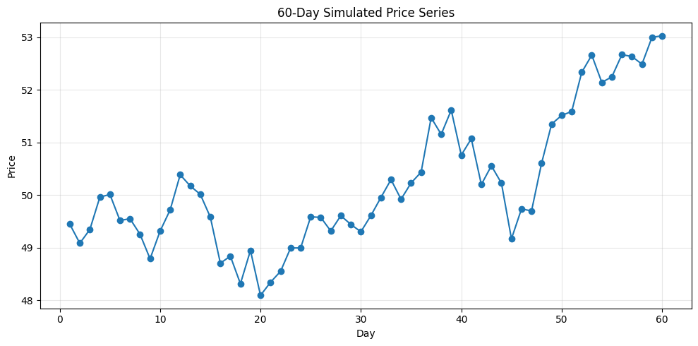

Interpretation Questions:

Why did you pick the seed value that you chose?

- It was the seed value I used all last semester based off my BU ID, if it's not broke don't fix it as they say!

What is the price on day 20 in your series?

- The price on day 20 is: 48.09138198838759

Does your series appear to trend up, down, or sideways?

- Overall the series does trend upwards but not by much, it starts at around 49.44 on Day 0 and finishes at roughly 53 dollars on day 60.

If you had to guess tomorrow’s price, what would you guess and why?

- I would guess somewhere in the region of 52.70 - 53.30 dollars. There is not much variation in the price from days 50-60 and overall it is rare that the price series sees any major jumps or drops in price from one day to the next.

Does your chart feel calm or volatile? Explain.

- Although the variation in price is small, the chart still feels volatile with it being hard to predict whether or not the price will increase or decrease from one day to the next. This job and rise in price is particularily evident if we look at the series from days 36 - 50.

```
price_on_day_20 = price_df[price_df['day'] == 20]['price'].item()
print(f"The price on day 20 is: {price_on_day_20}")
```

```
The price on day 20 is: 48.09138198838759
```

## PART 2 – Invent a Simple Trading Rule

Use the following rule:

If price > 52 → GO SHORT

If price < 48 → GO LONG

Otherwise HOLD

Assume that you start with no position. You are allowed to go long or go short.

Required outputs:

A plot showing price with BUY and SELL markers

A table listing day, price, position, and action.

```
position = 0
positions = []
actions = []

for p in price_df["price"]:
    if p > 52:
        if position != -1:
            position = -1
            action = "SELL (Go Short)"
        else:
            action = "HOLD"
    elif p < 48:
        if position != 1:
            position = 1
            action = "BUY (Go Long)"
        else:
            action = "HOLD"
    else:
        action = "HOLD"

    positions.append(position)
    actions.append(action)
```

```
price_df["position"] = positions
price_df["action"] = actions
```

```
display(price_df[["day", "price", "position", "action"]])
```

|  | day | price | position | action |
| --- | --- | --- | --- | --- |
| 0 | 1 | 49.445944 | 0 | HOLD |
| 1 | 2 | 49.083085 | 0 | HOLD |
| 2 | 3 | 49.344487 | 0 | HOLD |
| 3 | 4 | 49.961708 | 0 | HOLD |
| 4 | 5 | 50.010156 | 0 | HOLD |
| 5 | 6 | 49.516195 | 0 | HOLD |
| 6 | 7 | 49.549811 | 0 | HOLD |
| 7 | 8 | 49.253515 | 0 | HOLD |
| 8 | 9 | 48.787630 | 0 | HOLD |
| 9 | 10 | 49.315311 | 0 | HOLD |
| 10 | 11 | 49.717898 | 0 | HOLD |
| 11 | 12 | 50.385740 | 0 | HOLD |
| 12 | 13 | 50.173176 | 0 | HOLD |
| 13 | 14 | 50.013908 | 0 | HOLD |
| 14 | 15 | 49.581723 | 0 | HOLD |
| 15 | 16 | 48.705090 | 0 | HOLD |
| 16 | 17 | 48.837023 | 0 | HOLD |
| 17 | 18 | 48.313059 | 0 | HOLD |
| 18 | 19 | 48.946415 | 0 | HOLD |
| 19 | 20 | 48.091382 | 0 | HOLD |
| 20 | 21 | 48.341973 | 0 | HOLD |
| 21 | 22 | 48.549461 | 0 | HOLD |
| 22 | 23 | 48.993128 | 0 | HOLD |
| 23 | 24 | 48.993643 | 0 | HOLD |
| 24 | 25 | 49.586140 | 0 | HOLD |
| 25 | 26 | 49.574829 | 0 | HOLD |
| 26 | 27 | 49.316658 | 0 | HOLD |
| 27 | 28 | 49.607385 | 0 | HOLD |
| 28 | 29 | 49.441141 | 0 | HOLD |
| 29 | 30 | 49.301663 | 0 | HOLD |
| 30 | 31 | 49.610142 | 0 | HOLD |
| 31 | 32 | 49.954953 | 0 | HOLD |
| 32 | 33 | 50.293580 | 0 | HOLD |
| 33 | 34 | 49.919647 | 0 | HOLD |
| 34 | 35 | 50.229622 | 0 | HOLD |
| 35 | 36 | 50.435179 | 0 | HOLD |
| 36 | 37 | 51.471435 | 0 | HOLD |
| 37 | 38 | 51.154343 | 0 | HOLD |
| 38 | 39 | 51.614604 | 0 | HOLD |
| 39 | 40 | 50.759291 | 0 | HOLD |
| 40 | 41 | 51.071342 | 0 | HOLD |
| 41 | 42 | 50.199683 | 0 | HOLD |
| 42 | 43 | 50.556218 | 0 | HOLD |
| 43 | 44 | 50.226587 | 0 | HOLD |
| 44 | 45 | 49.166786 | 0 | HOLD |
| 45 | 46 | 49.736074 | 0 | HOLD |
| 46 | 47 | 49.697920 | 0 | HOLD |
| 47 | 48 | 50.603677 | 0 | HOLD |
| 48 | 49 | 51.350213 | 0 | HOLD |
| 49 | 50 | 51.514807 | 0 | HOLD |
| 50 | 51 | 51.588559 | 0 | HOLD |
| 51 | 52 | 52.333575 | -1 | SELL (Go Short) |
| 52 | 53 | 52.661152 | -1 | HOLD |
| 53 | 54 | 52.143036 | -1 | HOLD |
| 54 | 55 | 52.246993 | -1 | HOLD |
| 55 | 56 | 52.669650 | -1 | HOLD |
| 56 | 57 | 52.634973 | -1 | HOLD |
| 57 | 58 | 52.488657 | -1 | HOLD |
| 58 | 59 | 53.000295 | -1 | HOLD |
| 59 | 60 | 53.028081 | -1 | HOLD |

```
plt.figure(figsize=(10, 5))

plt.plot(price_df["day"], price_df["price"], marker="o", label="Price")

buy_df = price_df[price_df["action"] == "BUY (Go Long)"]
plt.scatter(buy_df["day"], buy_df["price"], marker="^", label="BUY")

sell_df = price_df[price_df["action"] == "SELL (Go Short)"]
plt.scatter(sell_df["day"], sell_df["price"], marker="v", label="SELL")

plt.title("Price Series with BUY and SELL Signals")
plt.xlabel("Day")
plt.ylabel("Price")
plt.grid(True, alpha=0.3)
plt.legend()
plt.tight_layout()
plt.show()
```

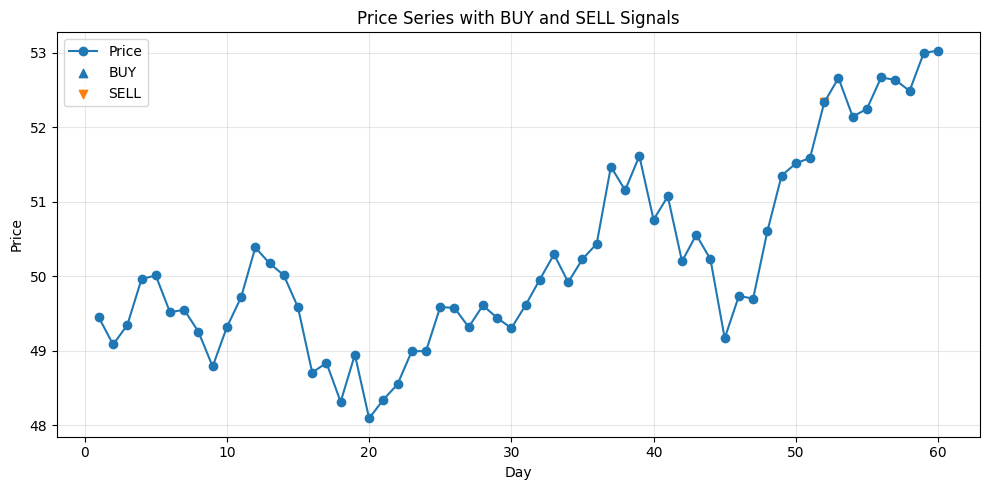

```
plt.figure(figsize=(10, 5))

plt.plot(price_df["day"], price_df["price"], linewidth=2, label="Price")

plt.axhline(52, linestyle="--", linewidth=1.5, label="Short Threshold (52)")
plt.axhline(48, linestyle="--", linewidth=1.5, label="Long Threshold (48)")

sell_df = price_df[price_df["action"] == "SELL (Go Short)"]

plt.scatter(
    sell_df["day"],
    sell_df["price"],
    s=200,
    marker="X",
    zorder=5,
    label="SELL Trade")

plt.xlim(45, 60)

plt.title("Zoomed View of Trading Signal")
plt.xlabel("Day")
plt.ylabel("Price")
plt.legend()
plt.grid(True, alpha=0.3)
plt.tight_layout()
plt.show()
```

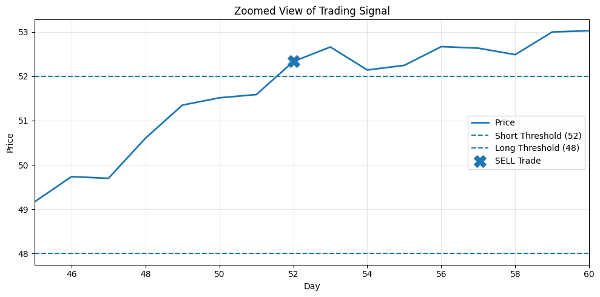

Interpretation Questions:

On what day did you make your first trade?

- Day 52

How many total trades did you make?

- 1

Does this rule feel reasonable for your series?

- Not particularily as the price in my series never dropped below 48 and is unlikely to do so if the trend is to continue. Therefore we are never at risk of triggering a long trade. To improve the strategy, I could either increase the level of random noise to allow for greater price fluctuation or tighten the trading band (e.g., short above 51 and long below 49) so that both sides of the strategy are realistically triggered.

Were there trades that look bad in hindsight?

- In hindsight, the short trade does not appear overly favorable. After entering the short position when price exceeded 52, the price continued to rise toward 53, which would result in unrealized losses. This suggests that the threshold may have triggered too early in what appears to be an upward-trending market. That being said, this rise is minimal and the price could yet drop again, further analysis would be needed over the coming 10-15 days.

## PART 3 – Turn Actions Into Money

Assume each unit position equals $1,000 of exposure. Compute daily profit and loss and cumulative P&L.

Required outputs:

Table displaying results for all 60 days, with P&L columns

Plot of cumulative P&L over time

```
price_df["price_change"] = price_df["price"].diff()

exposure = 1000

price_df["daily_pnl"] = (
    price_df["position"].shift(1).fillna(0)
    * price_df["price_change"]
    * exposure)

price_df["cumulative_pnl"] = price_df["daily_pnl"].cumsum()
```

```
display(price_df[[
    "day",
    "price",
    "position",
    "action",
    "daily_pnl",
    "cumulative_pnl"]])
```

|  | day | price | position | action | daily_pnl | cumulative_pnl |
| --- | --- | --- | --- | --- | --- | --- |
| 0 | 1 | 49.445944 | 0 | HOLD | NaN | NaN |
| 1 | 2 | 49.083085 | 0 | HOLD | -0.000000 | 0.000000 |
| 2 | 3 | 49.344487 | 0 | HOLD | 0.000000 | 0.000000 |
| 3 | 4 | 49.961708 | 0 | HOLD | 0.000000 | 0.000000 |
| 4 | 5 | 50.010156 | 0 | HOLD | 0.000000 | 0.000000 |
| 5 | 6 | 49.516195 | 0 | HOLD | -0.000000 | 0.000000 |
| 6 | 7 | 49.549811 | 0 | HOLD | 0.000000 | 0.000000 |
| 7 | 8 | 49.253515 | 0 | HOLD | -0.000000 | 0.000000 |
| 8 | 9 | 48.787630 | 0 | HOLD | -0.000000 | 0.000000 |
| 9 | 10 | 49.315311 | 0 | HOLD | 0.000000 | 0.000000 |
| 10 | 11 | 49.717898 | 0 | HOLD | 0.000000 | 0.000000 |
| 11 | 12 | 50.385740 | 0 | HOLD | 0.000000 | 0.000000 |
| 12 | 13 | 50.173176 | 0 | HOLD | -0.000000 | 0.000000 |
| 13 | 14 | 50.013908 | 0 | HOLD | -0.000000 | 0.000000 |
| 14 | 15 | 49.581723 | 0 | HOLD | -0.000000 | 0.000000 |
| 15 | 16 | 48.705090 | 0 | HOLD | -0.000000 | 0.000000 |
| 16 | 17 | 48.837023 | 0 | HOLD | 0.000000 | 0.000000 |
| 17 | 18 | 48.313059 | 0 | HOLD | -0.000000 | 0.000000 |
| 18 | 19 | 48.946415 | 0 | HOLD | 0.000000 | 0.000000 |
| 19 | 20 | 48.091382 | 0 | HOLD | -0.000000 | 0.000000 |
| 20 | 21 | 48.341973 | 0 | HOLD | 0.000000 | 0.000000 |
| 21 | 22 | 48.549461 | 0 | HOLD | 0.000000 | 0.000000 |
| 22 | 23 | 48.993128 | 0 | HOLD | 0.000000 | 0.000000 |
| 23 | 24 | 48.993643 | 0 | HOLD | 0.000000 | 0.000000 |
| 24 | 25 | 49.586140 | 0 | HOLD | 0.000000 | 0.000000 |
| 25 | 26 | 49.574829 | 0 | HOLD | -0.000000 | 0.000000 |
| 26 | 27 | 49.316658 | 0 | HOLD | -0.000000 | 0.000000 |
| 27 | 28 | 49.607385 | 0 | HOLD | 0.000000 | 0.000000 |
| 28 | 29 | 49.441141 | 0 | HOLD | -0.000000 | 0.000000 |
| 29 | 30 | 49.301663 | 0 | HOLD | -0.000000 | 0.000000 |
| 30 | 31 | 49.610142 | 0 | HOLD | 0.000000 | 0.000000 |
| 31 | 32 | 49.954953 | 0 | HOLD | 0.000000 | 0.000000 |
| 32 | 33 | 50.293580 | 0 | HOLD | 0.000000 | 0.000000 |
| 33 | 34 | 49.919647 | 0 | HOLD | -0.000000 | 0.000000 |
| 34 | 35 | 50.229622 | 0 | HOLD | 0.000000 | 0.000000 |
| 35 | 36 | 50.435179 | 0 | HOLD | 0.000000 | 0.000000 |
| 36 | 37 | 51.471435 | 0 | HOLD | 0.000000 | 0.000000 |
| 37 | 38 | 51.154343 | 0 | HOLD | -0.000000 | 0.000000 |
| 38 | 39 | 51.614604 | 0 | HOLD | 0.000000 | 0.000000 |
| 39 | 40 | 50.759291 | 0 | HOLD | -0.000000 | 0.000000 |
| 40 | 41 | 51.071342 | 0 | HOLD | 0.000000 | 0.000000 |
| 41 | 42 | 50.199683 | 0 | HOLD | -0.000000 | 0.000000 |
| 42 | 43 | 50.556218 | 0 | HOLD | 0.000000 | 0.000000 |
| 43 | 44 | 50.226587 | 0 | HOLD | -0.000000 | 0.000000 |
| 44 | 45 | 49.166786 | 0 | HOLD | -0.000000 | 0.000000 |
| 45 | 46 | 49.736074 | 0 | HOLD | 0.000000 | 0.000000 |
| 46 | 47 | 49.697920 | 0 | HOLD | -0.000000 | 0.000000 |
| 47 | 48 | 50.603677 | 0 | HOLD | 0.000000 | 0.000000 |
| 48 | 49 | 51.350213 | 0 | HOLD | 0.000000 | 0.000000 |
| 49 | 50 | 51.514807 | 0 | HOLD | 0.000000 | 0.000000 |
| 50 | 51 | 51.588559 | 0 | HOLD | 0.000000 | 0.000000 |
| 51 | 52 | 52.333575 | -1 | SELL (Go Short) | 0.000000 | 0.000000 |
| 52 | 53 | 52.661152 | -1 | HOLD | -327.577456 | -327.577456 |
| 53 | 54 | 52.143036 | -1 | HOLD | 518.116181 | 190.538725 |
| 54 | 55 | 52.246993 | -1 | HOLD | -103.956675 | 86.582051 |
| 55 | 56 | 52.669650 | -1 | HOLD | -422.657246 | -336.075195 |
| 56 | 57 | 52.634973 | -1 | HOLD | 34.676369 | -301.398826 |
| 57 | 58 | 52.488657 | -1 | HOLD | 146.316477 | -155.082349 |
| 58 | 59 | 53.000295 | -1 | HOLD | -511.638327 | -666.720676 |
| 59 | 60 | 53.028081 | -1 | HOLD | -27.785959 | -694.506635 |

```
plt.figure(figsize=(10, 5))
plt.plot(price_df["day"], price_df["cumulative_pnl"], linewidth=2)

plt.title("Cumulative P&L Over Time")
plt.xlabel("Day")
plt.ylabel("Cumulative P&L ($)")
plt.grid(True, alpha=0.3)
plt.tight_layout()
plt.show()
```

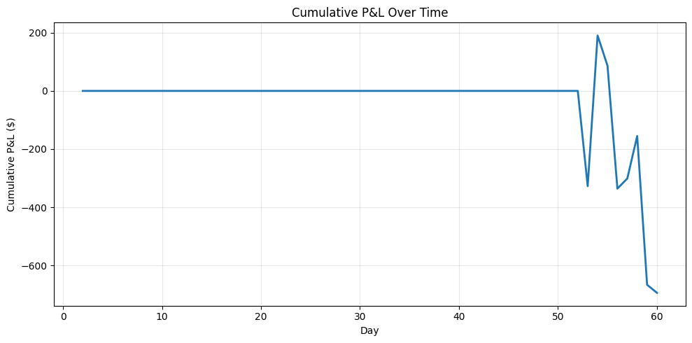

```
pnl_day_60 = price_df[price_df['day'] == 60]['cumulative_pnl'].item()
print(f"PNL on final day: {pnl_day_60}")
```

```
PNL on final day: -694.5066351377776
```

Interpretation Questions:

By day 30, were you up or down?

- By day 30, we were neither up nor down. No trades had been executed yet because price never crossed the 52 or 48 thresholds. However on day 54 things were looking good, we were up almost 200 dollars.

What is your final cumulative profit or loss?

- PNL on final day: -694.5066351377776

Did you experience a losing streak? How long was it?

- The longest consecutive losing streak was technically on 2 days however we are consistently in the red from day 56 - 60. Again, if the price trend is to continue I would expect us to continue to lose money unless we re-evaluate the trade.

## PART 4 – Add Leverage

Repeat the exact same trades but multiply trade size by 10.

Again, generate a table showing results for all 60 days, with P&L columns. Include both your 1x and your 10x results in this table.

Create equity curves for the 1× and 10× versions of your strategy, and plot both curves together on the same chart.

```
exposure_10x = 10000

price_df["daily_pnl_10x"] = (
    price_df["position"].shift(1).fillna(0)
    * price_df["price_change"]
    * exposure_10x)

price_df["cumulative_pnl_10x"] = price_df["daily_pnl_10x"].cumsum()
```

```
display(price_df[[
    "day",
    "price",
    "position",
    "daily_pnl",
    "cumulative_pnl",
    "daily_pnl_10x",
    "cumulative_pnl_10x"]])
```

|  | day | price | position | daily_pnl | cumulative_pnl | daily_pnl_10x | cumulative_pnl_10x |
| --- | --- | --- | --- | --- | --- | --- | --- |
| 0 | 1 | 49.445944 | 0 | NaN | NaN | NaN | NaN |
| 1 | 2 | 49.083085 | 0 | -0.000000 | 0.000000 | -0.000000 | 0.000000 |
| 2 | 3 | 49.344487 | 0 | 0.000000 | 0.000000 | 0.000000 | 0.000000 |
| 3 | 4 | 49.961708 | 0 | 0.000000 | 0.000000 | 0.000000 | 0.000000 |
| 4 | 5 | 50.010156 | 0 | 0.000000 | 0.000000 | 0.000000 | 0.000000 |
| 5 | 6 | 49.516195 | 0 | -0.000000 | 0.000000 | -0.000000 | 0.000000 |
| 6 | 7 | 49.549811 | 0 | 0.000000 | 0.000000 | 0.000000 | 0.000000 |
| 7 | 8 | 49.253515 | 0 | -0.000000 | 0.000000 | -0.000000 | 0.000000 |
| 8 | 9 | 48.787630 | 0 | -0.000000 | 0.000000 | -0.000000 | 0.000000 |
| 9 | 10 | 49.315311 | 0 | 0.000000 | 0.000000 | 0.000000 | 0.000000 |
| 10 | 11 | 49.717898 | 0 | 0.000000 | 0.000000 | 0.000000 | 0.000000 |
| 11 | 12 | 50.385740 | 0 | 0.000000 | 0.000000 | 0.000000 | 0.000000 |
| 12 | 13 | 50.173176 | 0 | -0.000000 | 0.000000 | -0.000000 | 0.000000 |
| 13 | 14 | 50.013908 | 0 | -0.000000 | 0.000000 | -0.000000 | 0.000000 |
| 14 | 15 | 49.581723 | 0 | -0.000000 | 0.000000 | -0.000000 | 0.000000 |
| 15 | 16 | 48.705090 | 0 | -0.000000 | 0.000000 | -0.000000 | 0.000000 |
| 16 | 17 | 48.837023 | 0 | 0.000000 | 0.000000 | 0.000000 | 0.000000 |
| 17 | 18 | 48.313059 | 0 | -0.000000 | 0.000000 | -0.000000 | 0.000000 |
| 18 | 19 | 48.946415 | 0 | 0.000000 | 0.000000 | 0.000000 | 0.000000 |
| 19 | 20 | 48.091382 | 0 | -0.000000 | 0.000000 | -0.000000 | 0.000000 |
| 20 | 21 | 48.341973 | 0 | 0.000000 | 0.000000 | 0.000000 | 0.000000 |
| 21 | 22 | 48.549461 | 0 | 0.000000 | 0.000000 | 0.000000 | 0.000000 |
| 22 | 23 | 48.993128 | 0 | 0.000000 | 0.000000 | 0.000000 | 0.000000 |
| 23 | 24 | 48.993643 | 0 | 0.000000 | 0.000000 | 0.000000 | 0.000000 |
| 24 | 25 | 49.586140 | 0 | 0.000000 | 0.000000 | 0.000000 | 0.000000 |
| 25 | 26 | 49.574829 | 0 | -0.000000 | 0.000000 | -0.000000 | 0.000000 |
| 26 | 27 | 49.316658 | 0 | -0.000000 | 0.000000 | -0.000000 | 0.000000 |
| 27 | 28 | 49.607385 | 0 | 0.000000 | 0.000000 | 0.000000 | 0.000000 |
| 28 | 29 | 49.441141 | 0 | -0.000000 | 0.000000 | -0.000000 | 0.000000 |
| 29 | 30 | 49.301663 | 0 | -0.000000 | 0.000000 | -0.000000 | 0.000000 |
| 30 | 31 | 49.610142 | 0 | 0.000000 | 0.000000 | 0.000000 | 0.000000 |
| 31 | 32 | 49.954953 | 0 | 0.000000 | 0.000000 | 0.000000 | 0.000000 |
| 32 | 33 | 50.293580 | 0 | 0.000000 | 0.000000 | 0.000000 | 0.000000 |
| 33 | 34 | 49.919647 | 0 | -0.000000 | 0.000000 | -0.000000 | 0.000000 |
| 34 | 35 | 50.229622 | 0 | 0.000000 | 0.000000 | 0.000000 | 0.000000 |
| 35 | 36 | 50.435179 | 0 | 0.000000 | 0.000000 | 0.000000 | 0.000000 |
| 36 | 37 | 51.471435 | 0 | 0.000000 | 0.000000 | 0.000000 | 0.000000 |
| 37 | 38 | 51.154343 | 0 | -0.000000 | 0.000000 | -0.000000 | 0.000000 |
| 38 | 39 | 51.614604 | 0 | 0.000000 | 0.000000 | 0.000000 | 0.000000 |
| 39 | 40 | 50.759291 | 0 | -0.000000 | 0.000000 | -0.000000 | 0.000000 |
| 40 | 41 | 51.071342 | 0 | 0.000000 | 0.000000 | 0.000000 | 0.000000 |
| 41 | 42 | 50.199683 | 0 | -0.000000 | 0.000000 | -0.000000 | 0.000000 |
| 42 | 43 | 50.556218 | 0 | 0.000000 | 0.000000 | 0.000000 | 0.000000 |
| 43 | 44 | 50.226587 | 0 | -0.000000 | 0.000000 | -0.000000 | 0.000000 |
| 44 | 45 | 49.166786 | 0 | -0.000000 | 0.000000 | -0.000000 | 0.000000 |
| 45 | 46 | 49.736074 | 0 | 0.000000 | 0.000000 | 0.000000 | 0.000000 |
| 46 | 47 | 49.697920 | 0 | -0.000000 | 0.000000 | -0.000000 | 0.000000 |
| 47 | 48 | 50.603677 | 0 | 0.000000 | 0.000000 | 0.000000 | 0.000000 |
| 48 | 49 | 51.350213 | 0 | 0.000000 | 0.000000 | 0.000000 | 0.000000 |
| 49 | 50 | 51.514807 | 0 | 0.000000 | 0.000000 | 0.000000 | 0.000000 |
| 50 | 51 | 51.588559 | 0 | 0.000000 | 0.000000 | 0.000000 | 0.000000 |
| 51 | 52 | 52.333575 | -1 | 0.000000 | 0.000000 | 0.000000 | 0.000000 |
| 52 | 53 | 52.661152 | -1 | -327.577456 | -327.577456 | -3275.774558 | -3275.774558 |
| 53 | 54 | 52.143036 | -1 | 518.116181 | 190.538725 | 5181.161810 | 1905.387253 |
| 54 | 55 | 52.246993 | -1 | -103.956675 | 86.582051 | -1039.566747 | 865.820506 |
| 55 | 56 | 52.669650 | -1 | -422.657246 | -336.075195 | -4226.572460 | -3360.751954 |
| 56 | 57 | 52.634973 | -1 | 34.676369 | -301.398826 | 346.763694 | -3013.988259 |
| 57 | 58 | 52.488657 | -1 | 146.316477 | -155.082349 | 1463.164767 | -1550.823493 |
| 58 | 59 | 53.000295 | -1 | -511.638327 | -666.720676 | -5116.383268 | -6667.206761 |
| 59 | 60 | 53.028081 | -1 | -27.785959 | -694.506635 | -277.859590 | -6945.066351 |

```
plt.figure(figsize=(10, 5))

plt.plot(price_df["day"], price_df["cumulative_pnl"], linewidth=2, label="1× Strategy")
plt.plot(price_df["day"], price_df["cumulative_pnl_10x"], linewidth=2, linestyle="--", label="10× Strategy")

plt.title("Equity Curves: 1× vs 10× Leverage")
plt.xlabel("Day")
plt.ylabel("Cumulative P&L ($)")
plt.legend()
plt.grid(True, alpha=0.3)
plt.tight_layout()
plt.show()
```

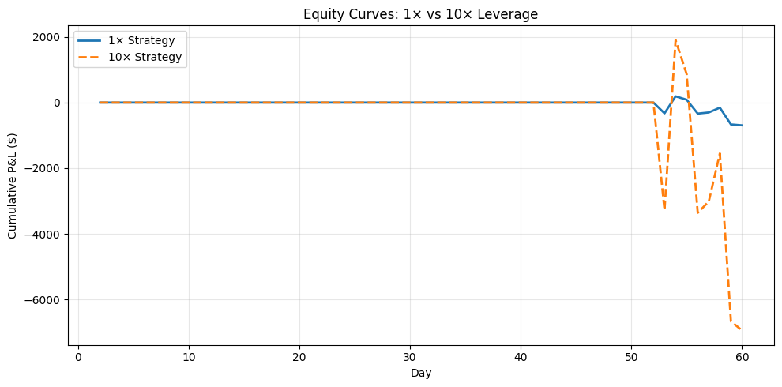

```
pnl_day_60_lev = price_df[price_df['day'] == 60]['cumulative_pnl_10x'].item()
print(f"PNL leveraged on final day: {pnl_day_60_lev}")
```

```
PNL leveraged on final day: -6945.066351377775
```

```
pnl_lev_max = price_df['cumulative_pnl_10x'].max()
print(f"PNL leveraged max: {pnl_lev_max}")
```

```
PNL leveraged max: 1905.3872527205585
```

Interpretation Questions:

Did leverage change your final profit?

- It just multiplied my losses x10, leaving final PNL at -6945.07 dollars.

Did leverage change how scary the ride felt?

- Yes! We can see how in the space of 7 days we went from being up almost 2k to being down 7k, a swing of around 9k.

What was the highest equity value you reached?

- 1905.39 dollars.

After that point, how far did equity fall at its worst?”

- From this point as mentioned, equity fell roughly 9k to -6945.07.

On what day did it occur?

- The largest single-day loss occurred on Day 59 (-5,116). However, the cumulative equity reached its lowest point of –6,945.07 on day 60.

## PART 5 – Introduce a Survival Rule

Apply the rule: if 10x equity ever drops below –$2,000, you must stop trading

```
price_df["position_survival"] = price_df["position"].copy()

stop_index = price_df[price_df["cumulative_pnl_10x"] < -2000].index

if len(stop_index) > 0:
    first_stop_day = stop_index[0]

    price_df.loc[first_stop_day:, "position_survival"] = 0
else:
    first_stop_day = None
```

```
price_df["daily_pnl_10x_survival"] = (
    price_df["position_survival"].shift(1).fillna(0)
    * price_df["price_change"]
    * 10000)
```

```
price_df["cumulative_pnl_10x_survival"] = (
    price_df["daily_pnl_10x_survival"].cumsum())
```

```
display(price_df[[
    "day",
    "position_survival",
    "daily_pnl_10x_survival",
    "cumulative_pnl_10x_survival"]])
```

|  | day | position_survival | daily_pnl_10x_survival | cumulative_pnl_10x_survival |
| --- | --- | --- | --- | --- |
| 0 | 1 | 0 | NaN | NaN |
| 1 | 2 | 0 | -0.000000 | 0.000000 |
| 2 | 3 | 0 | 0.000000 | 0.000000 |
| 3 | 4 | 0 | 0.000000 | 0.000000 |
| 4 | 5 | 0 | 0.000000 | 0.000000 |
| 5 | 6 | 0 | -0.000000 | 0.000000 |
| 6 | 7 | 0 | 0.000000 | 0.000000 |
| 7 | 8 | 0 | -0.000000 | 0.000000 |
| 8 | 9 | 0 | -0.000000 | 0.000000 |
| 9 | 10 | 0 | 0.000000 | 0.000000 |
| 10 | 11 | 0 | 0.000000 | 0.000000 |
| 11 | 12 | 0 | 0.000000 | 0.000000 |
| 12 | 13 | 0 | -0.000000 | 0.000000 |
| 13 | 14 | 0 | -0.000000 | 0.000000 |
| 14 | 15 | 0 | -0.000000 | 0.000000 |
| 15 | 16 | 0 | -0.000000 | 0.000000 |
| 16 | 17 | 0 | 0.000000 | 0.000000 |
| 17 | 18 | 0 | -0.000000 | 0.000000 |
| 18 | 19 | 0 | 0.000000 | 0.000000 |
| 19 | 20 | 0 | -0.000000 | 0.000000 |
| 20 | 21 | 0 | 0.000000 | 0.000000 |
| 21 | 22 | 0 | 0.000000 | 0.000000 |
| 22 | 23 | 0 | 0.000000 | 0.000000 |
| 23 | 24 | 0 | 0.000000 | 0.000000 |
| 24 | 25 | 0 | 0.000000 | 0.000000 |
| 25 | 26 | 0 | -0.000000 | 0.000000 |
| 26 | 27 | 0 | -0.000000 | 0.000000 |
| 27 | 28 | 0 | 0.000000 | 0.000000 |
| 28 | 29 | 0 | -0.000000 | 0.000000 |
| 29 | 30 | 0 | -0.000000 | 0.000000 |
| 30 | 31 | 0 | 0.000000 | 0.000000 |
| 31 | 32 | 0 | 0.000000 | 0.000000 |
| 32 | 33 | 0 | 0.000000 | 0.000000 |
| 33 | 34 | 0 | -0.000000 | 0.000000 |
| 34 | 35 | 0 | 0.000000 | 0.000000 |
| 35 | 36 | 0 | 0.000000 | 0.000000 |
| 36 | 37 | 0 | 0.000000 | 0.000000 |
| 37 | 38 | 0 | -0.000000 | 0.000000 |
| 38 | 39 | 0 | 0.000000 | 0.000000 |
| 39 | 40 | 0 | -0.000000 | 0.000000 |
| 40 | 41 | 0 | 0.000000 | 0.000000 |
| 41 | 42 | 0 | -0.000000 | 0.000000 |
| 42 | 43 | 0 | 0.000000 | 0.000000 |
| 43 | 44 | 0 | -0.000000 | 0.000000 |
| 44 | 45 | 0 | -0.000000 | 0.000000 |
| 45 | 46 | 0 | 0.000000 | 0.000000 |
| 46 | 47 | 0 | -0.000000 | 0.000000 |
| 47 | 48 | 0 | 0.000000 | 0.000000 |
| 48 | 49 | 0 | 0.000000 | 0.000000 |
| 49 | 50 | 0 | 0.000000 | 0.000000 |
| 50 | 51 | 0 | 0.000000 | 0.000000 |
| 51 | 52 | -1 | 0.000000 | 0.000000 |
| 52 | 53 | 0 | -3275.774558 | -3275.774558 |
| 53 | 54 | 0 | -0.000000 | -3275.774558 |
| 54 | 55 | 0 | 0.000000 | -3275.774558 |
| 55 | 56 | 0 | 0.000000 | -3275.774558 |
| 56 | 57 | 0 | -0.000000 | -3275.774558 |
| 57 | 58 | 0 | -0.000000 | -3275.774558 |
| 58 | 59 | 0 | 0.000000 | -3275.774558 |
| 59 | 60 | 0 | 0.000000 | -3275.774558 |

Interpretation Questions:

Did you hit the stop‑loss rule? If yes, on what day?

- Yes we did, on day 53.

If you had been allowed to continue, would the strategy have recovered?

- The strategy would have recovered briefly through day's 54 & 55, however we would've hit the stop loss rule again on day 56.

In your simulation, was the strategy good or unsafe? Explain.

- The underlying strategy appears unsafe because it shorted into an upward-trending market and generated massive losses under leverage. However, the survival rule was effective in limiting damage, reducing the final loss from roughly 7k down to 3.2k.

## PART 6 – A Tiny Shock

Choose a 3‑day window that includes at least one trade, and artificially increase the price by +4 for those days.

Re‑run the 10x strategy with the stop‑loss rule

```
shock_df = price_df.copy()

shock_days = [52, 53, 54]

shock_df.loc[shock_df["day"].isin(shock_days), "price"] += 4
```

```
shock_df["price_change"] = shock_df["price"].diff()
```

```
exposure_10x = 10000

shock_df["daily_pnl_10x"] = (
    shock_df["position"].shift(1).fillna(0)
    * shock_df["price_change"]
    * exposure_10x)

shock_df["cumulative_pnl_10x"] = shock_df["daily_pnl_10x"].cumsum()
```

```
shock_df["position_survival"] = shock_df["position"].copy()

stop_index = shock_df[shock_df["cumulative_pnl_10x"] < -2000].index

if len(stop_index) > 0:
    first_stop_day = stop_index[0]
    shock_df.loc[first_stop_day:, "position_survival"] = 0
else:
    first_stop_day = None
```

```
shock_df["daily_pnl_10x_survival"] = (
    shock_df["position_survival"].shift(1).fillna(0)
    * shock_df["price_change"]
    * exposure_10x)

shock_df["cumulative_pnl_10x_survival"] = (
    shock_df["daily_pnl_10x_survival"].cumsum())
```

```
display(shock_df[[
    "day",
    "price",
    "position_survival",
    "cumulative_pnl_10x_survival"]])
```

|  | day | price | position_survival | cumulative_pnl_10x_survival |
| --- | --- | --- | --- | --- |
| 0 | 1 | 49.445944 | 0 | NaN |
| 1 | 2 | 49.083085 | 0 | 0.000000 |
| 2 | 3 | 49.344487 | 0 | 0.000000 |
| 3 | 4 | 49.961708 | 0 | 0.000000 |
| 4 | 5 | 50.010156 | 0 | 0.000000 |
| 5 | 6 | 49.516195 | 0 | 0.000000 |
| 6 | 7 | 49.549811 | 0 | 0.000000 |
| 7 | 8 | 49.253515 | 0 | 0.000000 |
| 8 | 9 | 48.787630 | 0 | 0.000000 |
| 9 | 10 | 49.315311 | 0 | 0.000000 |
| 10 | 11 | 49.717898 | 0 | 0.000000 |
| 11 | 12 | 50.385740 | 0 | 0.000000 |
| 12 | 13 | 50.173176 | 0 | 0.000000 |
| 13 | 14 | 50.013908 | 0 | 0.000000 |
| 14 | 15 | 49.581723 | 0 | 0.000000 |
| 15 | 16 | 48.705090 | 0 | 0.000000 |
| 16 | 17 | 48.837023 | 0 | 0.000000 |
| 17 | 18 | 48.313059 | 0 | 0.000000 |
| 18 | 19 | 48.946415 | 0 | 0.000000 |
| 19 | 20 | 48.091382 | 0 | 0.000000 |
| 20 | 21 | 48.341973 | 0 | 0.000000 |
| 21 | 22 | 48.549461 | 0 | 0.000000 |
| 22 | 23 | 48.993128 | 0 | 0.000000 |
| 23 | 24 | 48.993643 | 0 | 0.000000 |
| 24 | 25 | 49.586140 | 0 | 0.000000 |
| 25 | 26 | 49.574829 | 0 | 0.000000 |
| 26 | 27 | 49.316658 | 0 | 0.000000 |
| 27 | 28 | 49.607385 | 0 | 0.000000 |
| 28 | 29 | 49.441141 | 0 | 0.000000 |
| 29 | 30 | 49.301663 | 0 | 0.000000 |
| 30 | 31 | 49.610142 | 0 | 0.000000 |
| 31 | 32 | 49.954953 | 0 | 0.000000 |
| 32 | 33 | 50.293580 | 0 | 0.000000 |
| 33 | 34 | 49.919647 | 0 | 0.000000 |
| 34 | 35 | 50.229622 | 0 | 0.000000 |
| 35 | 36 | 50.435179 | 0 | 0.000000 |
| 36 | 37 | 51.471435 | 0 | 0.000000 |
| 37 | 38 | 51.154343 | 0 | 0.000000 |
| 38 | 39 | 51.614604 | 0 | 0.000000 |
| 39 | 40 | 50.759291 | 0 | 0.000000 |
| 40 | 41 | 51.071342 | 0 | 0.000000 |
| 41 | 42 | 50.199683 | 0 | 0.000000 |
| 42 | 43 | 50.556218 | 0 | 0.000000 |
| 43 | 44 | 50.226587 | 0 | 0.000000 |
| 44 | 45 | 49.166786 | 0 | 0.000000 |
| 45 | 46 | 49.736074 | 0 | 0.000000 |
| 46 | 47 | 49.697920 | 0 | 0.000000 |
| 47 | 48 | 50.603677 | 0 | 0.000000 |
| 48 | 49 | 51.350213 | 0 | 0.000000 |
| 49 | 50 | 51.514807 | 0 | 0.000000 |
| 50 | 51 | 51.588559 | 0 | 0.000000 |
| 51 | 52 | 56.333575 | -1 | 0.000000 |
| 52 | 53 | 56.661152 | 0 | -3275.774558 |
| 53 | 54 | 56.143036 | 0 | -3275.774558 |
| 54 | 55 | 52.246993 | 0 | -3275.774558 |
| 55 | 56 | 52.669650 | 0 | -3275.774558 |
| 56 | 57 | 52.634973 | 0 | -3275.774558 |
| 57 | 58 | 52.488657 | 0 | -3275.774558 |
| 58 | 59 | 53.000295 | 0 | -3275.774558 |
| 59 | 60 | 53.028081 | 0 | -3275.774558 |

Interpretation Questions:

Did the shock change your final profit?

- No, the rule was still implemented on the same day, because trading stopped immediately in both cases, the final cumulative P&L remained the same.

Did it change whether you survived?

- No. The strategy still breached the –2,000 threshold on Day 53, so trading stopped at the same point. Therefore, the survival outcome did not change.

What mattered more: the rule or short‑run luck?

## Optional Alternative Part 6

```
shock_df = price_df.copy()

shock_days = [52, 53, 54]
shock_df.loc[shock_df["day"].isin(shock_days), "price"] -= 4
```

```
shock_df["price_change"] = shock_df["price"].diff()

exposure_10x = 10000

shock_df["daily_pnl_10x"] = (
    shock_df["position"].shift(1).fillna(0)
    * shock_df["price_change"]
    * exposure_10x
)

shock_df["cumulative_pnl_10x"] = shock_df["daily_pnl_10x"].cumsum()
```

```
shock_df["position_survival"] = shock_df["position"].copy()

stop_idx = shock_df[shock_df["cumulative_pnl_10x"] < -2000].index

if len(stop_idx) > 0:
    first_stop = stop_idx[0]
    shock_df.loc[first_stop:, "position_survival"] = 0
else:
    first_stop = None

shock_df["daily_pnl_10x_survival"] = (
    shock_df["position_survival"].shift(1).fillna(0)
    * shock_df["price_change"]
    * exposure_10x
)

shock_df["cumulative_pnl_10x_survival"] = (
    shock_df["daily_pnl_10x_survival"].cumsum()
)


display(shock_df[[
    "day",
    "price",
    "position_survival",
    "cumulative_pnl_10x_survival"
]])
```

|  | day | price | position_survival | cumulative_pnl_10x_survival |
| --- | --- | --- | --- | --- |
| 0 | 1 | 49.445944 | 0 | NaN |
| 1 | 2 | 49.083085 | 0 | 0.000000 |
| 2 | 3 | 49.344487 | 0 | 0.000000 |
| 3 | 4 | 49.961708 | 0 | 0.000000 |
| 4 | 5 | 50.010156 | 0 | 0.000000 |
| 5 | 6 | 49.516195 | 0 | 0.000000 |
| 6 | 7 | 49.549811 | 0 | 0.000000 |
| 7 | 8 | 49.253515 | 0 | 0.000000 |
| 8 | 9 | 48.787630 | 0 | 0.000000 |
| 9 | 10 | 49.315311 | 0 | 0.000000 |
| 10 | 11 | 49.717898 | 0 | 0.000000 |
| 11 | 12 | 50.385740 | 0 | 0.000000 |
| 12 | 13 | 50.173176 | 0 | 0.000000 |
| 13 | 14 | 50.013908 | 0 | 0.000000 |
| 14 | 15 | 49.581723 | 0 | 0.000000 |
| 15 | 16 | 48.705090 | 0 | 0.000000 |
| 16 | 17 | 48.837023 | 0 | 0.000000 |
| 17 | 18 | 48.313059 | 0 | 0.000000 |
| 18 | 19 | 48.946415 | 0 | 0.000000 |
| 19 | 20 | 48.091382 | 0 | 0.000000 |
| 20 | 21 | 48.341973 | 0 | 0.000000 |
| 21 | 22 | 48.549461 | 0 | 0.000000 |
| 22 | 23 | 48.993128 | 0 | 0.000000 |
| 23 | 24 | 48.993643 | 0 | 0.000000 |
| 24 | 25 | 49.586140 | 0 | 0.000000 |
| 25 | 26 | 49.574829 | 0 | 0.000000 |
| 26 | 27 | 49.316658 | 0 | 0.000000 |
| 27 | 28 | 49.607385 | 0 | 0.000000 |
| 28 | 29 | 49.441141 | 0 | 0.000000 |
| 29 | 30 | 49.301663 | 0 | 0.000000 |
| 30 | 31 | 49.610142 | 0 | 0.000000 |
| 31 | 32 | 49.954953 | 0 | 0.000000 |
| 32 | 33 | 50.293580 | 0 | 0.000000 |
| 33 | 34 | 49.919647 | 0 | 0.000000 |
| 34 | 35 | 50.229622 | 0 | 0.000000 |
| 35 | 36 | 50.435179 | 0 | 0.000000 |
| 36 | 37 | 51.471435 | 0 | 0.000000 |
| 37 | 38 | 51.154343 | 0 | 0.000000 |
| 38 | 39 | 51.614604 | 0 | 0.000000 |
| 39 | 40 | 50.759291 | 0 | 0.000000 |
| 40 | 41 | 51.071342 | 0 | 0.000000 |
| 41 | 42 | 50.199683 | 0 | 0.000000 |
| 42 | 43 | 50.556218 | 0 | 0.000000 |
| 43 | 44 | 50.226587 | 0 | 0.000000 |
| 44 | 45 | 49.166786 | 0 | 0.000000 |
| 45 | 46 | 49.736074 | 0 | 0.000000 |
| 46 | 47 | 49.697920 | 0 | 0.000000 |
| 47 | 48 | 50.603677 | 0 | 0.000000 |
| 48 | 49 | 51.350213 | 0 | 0.000000 |
| 49 | 50 | 51.514807 | 0 | 0.000000 |
| 50 | 51 | 51.588559 | 0 | 0.000000 |
| 51 | 52 | 48.333575 | -1 | 0.000000 |
| 52 | 53 | 48.661152 | 0 | -3275.774558 |
| 53 | 54 | 48.143036 | 0 | -3275.774558 |
| 54 | 55 | 52.246993 | 0 | -3275.774558 |
| 55 | 56 | 52.669650 | 0 | -3275.774558 |
| 56 | 57 | 52.634973 | 0 | -3275.774558 |
| 57 | 58 | 52.488657 | 0 | -3275.774558 |
| 58 | 59 | 53.000295 | 0 | -3275.774558 |
| 59 | 60 | 53.028081 | 0 | -3275.774558 |